# Lab 8: Data Science to Solve Problems and Answer Questions, part 1

Brandon Nelsen, Tanner Ball, Burke Parent, Drew Hoffman, David Washburn

10/14/2019

*Team Portion*

**1. Who is hiring us?**

We are being hired by the commissioner of Major League Baseball to analyze differences in hitting and pitching data between the National League and the American League.

**2. Overall Team Question**

The overall question is as follows: How do rule differences affect changes in play, statistics, and roster creation between the National League and the American League? This is important because there is one significant rule difference between the two leagues. The American League does not have to send their pitchers up to bat and can instead send out a “Designated Hitter” whose only job is to hit for the pitcher and not play the field. This is because pitchers are traditionally weak batters and don’t provide much hitting value. This affects lineup order and roster creation because there are different roles and game situations that players in each league have to face. There is much debate over the Designated Hitter, with baseball purists opposing the rule and supporters of the DH cite the fact that it provides slightly more offense and excitement in the games. Major League Baseball has hired us to determine the effects of the DH on league hitting and pitching statistics as well as overall gameplay to settle the debate once and for all.

**3. Dataset description**

Baseball-reference.com is a great resource for baseball data, as it is a hub for every bit of baseball information and statistics that humans have ever recorded. They allow you to export csv’s of their data to be analyzed externally and we will be gathering our data from there. We will be looking at pitching and hitting statistics over the last season of baseball.

**4. Individual questions**

*Are there differences in the hitting statistics of pitchers themselves between the National League and American League?*

This question is important because while American League pitchers usually do not have to hit, if they are playing an away game at a National League park then they have to, because of house rules. It would be interesting to see if pitchers from both leagues are poor hitters or if there is a tangible difference.

*Do the different player roles affect roster creation?*

On an MLB team, there are 25 roster spots for the players. It is up to the team to decide what quantity of pitchers and hitters to carry. Because there is a position that only exists in one of the leagues, there may be a different prevailing theory for how many of each player type to carry on roster.

*How does the extra hitter in the lineup affect pitching statistics?*

Because American League pitchers are facing 9 professional hitters as opposed to 8 and a pitcher in the National League, it may alter statistics of pitchers from either side. If an American league pitcher gave up 3 runs per game and a National League pitcher gave up 2 runs per game, it becomes more difficult to determine the better player becasue of different circumstances and environment.

*How does the designated hitter affect game strategy?*

Due to the poor hitting of pitchers, they will often be asked to perform a “sacrifice bunt”. The idea is that the pitcher can essentially give himself up as an out by bunting the ball a few feet in order to advance the runners on base. It is a strategic choice to trade what would have already been a likely out from the pitcher into moving your runners closer to home. This is one obvious tactical difference, but there may be other hidden strategies that teams can take advantage of.

*Is the American League more friendly to heavier players?*

The traditional designated hitter is a player that provides great value at the plate, but their defense is either severely lacking or not needed on the team. The stereotypical body type of this individual is an overweight player who doesn’t want to worry about being a detriment on the field. We can analyze height and weight data of players in both leagues to determine if the American League teams have a higher likelihood of signing or trading for heavier players, as they have a role that fits their skillset.

**5. Individual visualizations of the East Africa Lake Data. Plots for Challa, Tanganyika, Malawi, CRU and MAM rainfall, and VOI rainfall.**

Challa Data Set

```
## # A tibble: 3,056 x 5
##     year number thickness dark.layer light.layer
##    <dbl>  <dbl>     <dbl>      <dbl>       <dbl>
##  1  2005      1      1.06       0.08        0.98
##  2  2004      2      1.3        0.1         1.2
##  3  2003      3      0.8        0.12        0.68
##  4  2002      4      0.7        0.2         0.5
##  5  2001      5      0.3        0.14        0.16
##  6  2000      6      0.2        0.1         0.1
##  7  1999      7      1.5        0.2         1.3
##  8  1998      8      0.5        0.3         0.2
##  9  1997      9      1.8        0.3         1.5
## 10  1996     10      1.6        0.26        1.34
## # ... with 3,046 more rows
```

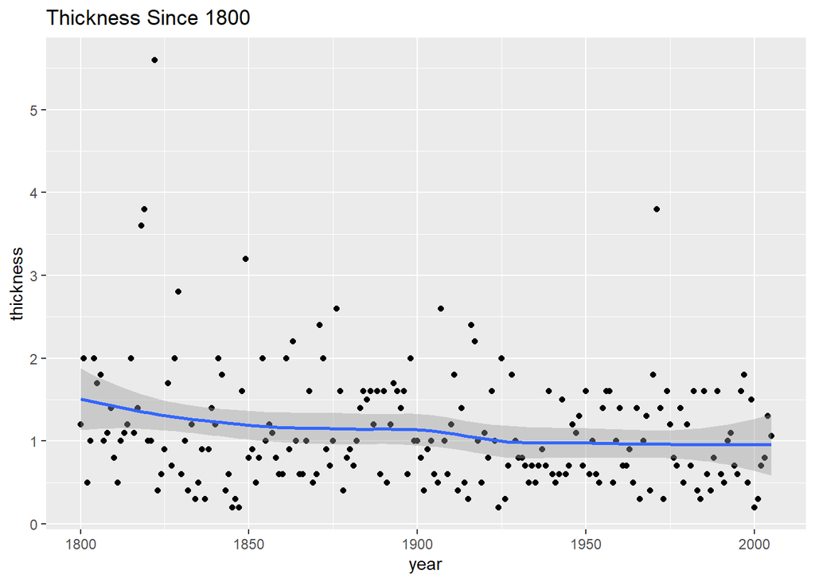

Tanganyika Data Set

```
## # A tibble: 139 x 4
##     year   BSi charcoal  TEX86
##    <dbl> <dbl>    <dbl>  <dbl>
##  1  1996 -1.26   NA      0.752
##  2  1986 -1.34   NA      0.749
##  3  1976 -1.37   -0.45   0.733
##  4  1966 -1.41   -0.6    0.722
##  5  1956 -1.39   -0.78   0.72
##  6  1946 -1.45   -0.580  0.71
##  7  1937 -1.35   NA     NA
##  8  1927 -1.11   NA     NA
##  9  1918 -0.89   -0.69   0.709
## 10  1908 -0.06   -0.44  NA
## # ... with 129 more rows
```

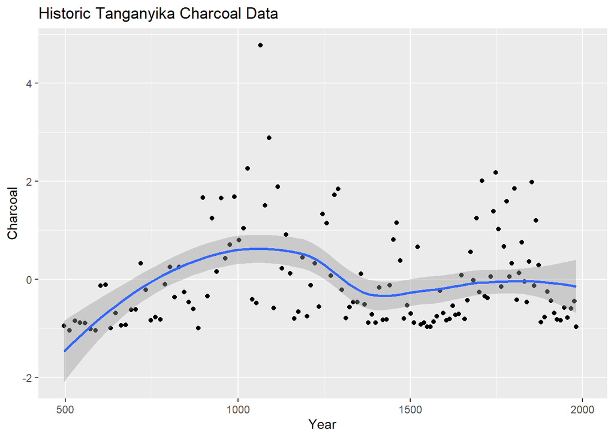

Malawi Data Set

```
## * `` -> ...4
## * `` -> ...5
## * ... and 1 more problem
```

```
## [1] "Age, ybp"                  "Age (calender)...2"
## [3] "BSi MAR (mgSiO2/cm2y)...3" "...4"
## [5] "...5"                      "Age, cal ybp"
## [7] "Age (calender)...7"        "BSi MAR (mgSiO2/cm2y)...8"
```

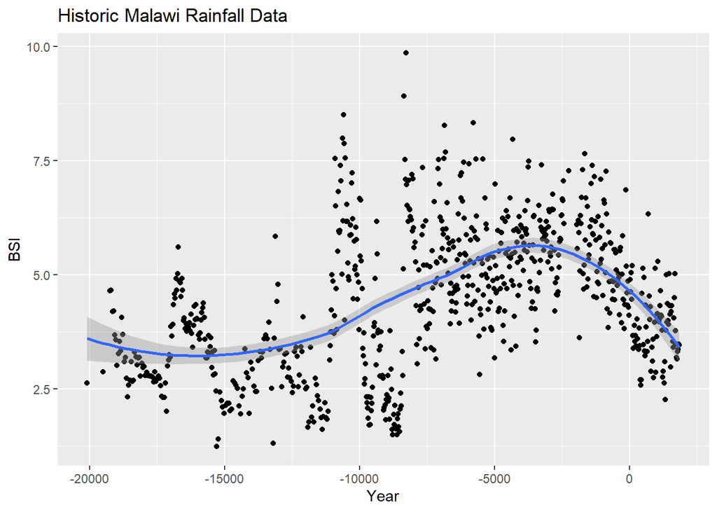

CRU and GPCC Data Set

```
## [1] "Year"                "GPCC MAM Normalized" "CRU MAM Normalized"
## [4] "GPCC OND Normalized" "CRU OND Normalized"  "X6"
## [7] "X7"                  "X8"
```

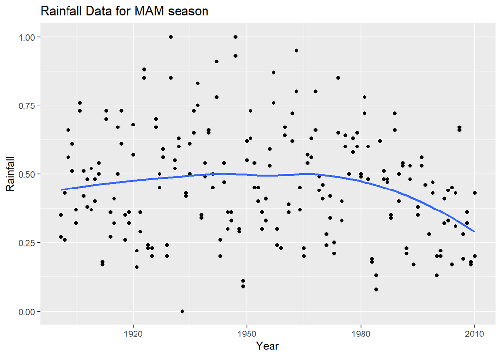

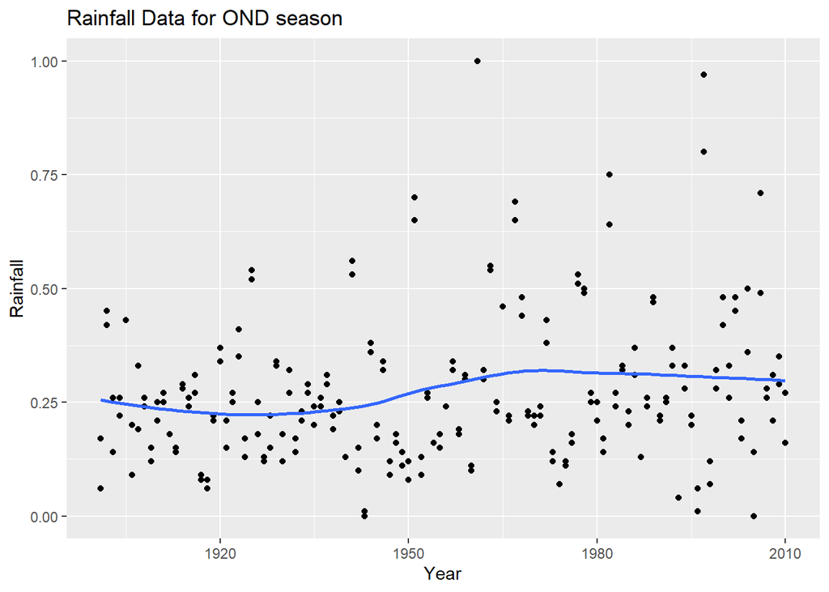

VOI Data Set

```r
VOI <- read_xlsx("East Africa lake data.xlsx", sheet = "VOI rainfall station data")
```

```
## * `` -> ...14
## * `` -> ...15
```

```r
VOI <- gather(VOI,Jan,Feb,Mar,Apr,May,Jun,Jul,Aug,Sep,Oct,Nov,Dec,key=month,value=rainfall)
VOI <- select(VOI, "Year", "month", "rainfall")

VOI1904 <- filter(VOI, Year == 1904)
sum(VOI1904$rainfall) # =6430
```

```
## [1] 6430
```

```r
VOI1927 <- filter(VOI, Year == 1927)
sum(VOI1927$rainfall) # =12035
```

```
## [1] 12035
```

```r
VOI1950 <- filter(VOI, Year == 1950)
sum(VOI1950$rainfall) # =3450
```

```
## [1] 3450
```

```r
VOI1973 <- filter(VOI, Year == 1973)
sum(VOI1973$rainfall) # =4689
```

```
## [1] 4689
```

```r
VOI1996 <- filter(VOI, Year == 1996)
sum(VOI1996$rainfall, na.rm = TRUE) # =4780
```

```
## [1] 4780
```

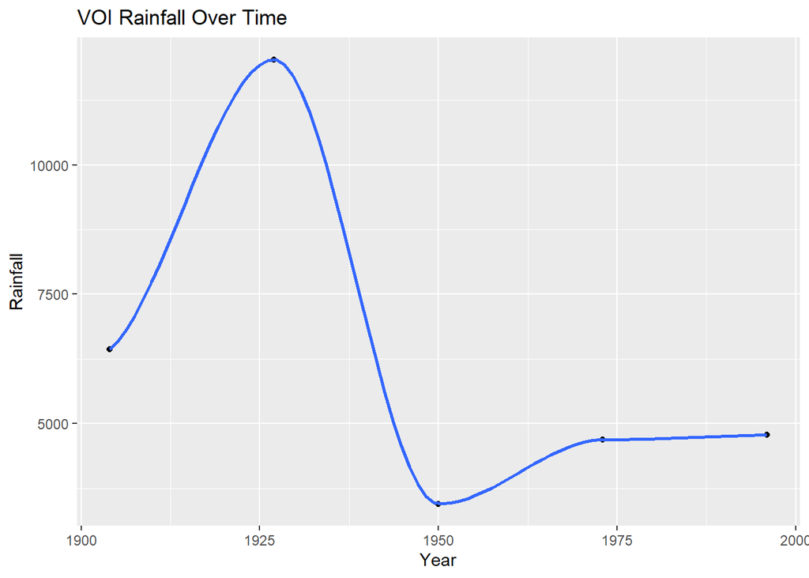

```r
NewVOI <- data.frame("Year" = c(1904, 1927, 1950, 1973, 1996),
                 "Rainfall" = c(6430, 12035, 3450, 4689, 4780))

ggplot(NewVOI, aes(Year, Rainfall)) +
  geom_point() +geom_smooth(se = 0) +
  ggtitle("VOI Rainfall Over Time")
```